# Tidymodels Workflow Report: Penguin Classification

Author

Automated Pipeline with `targets` and `tidymodels`

Published

May 30, 2025

## Introduction

We explore four classification algorithms:

- k-Nearest Neighbors (kNN)
- Support Vector Machine (SVM) with a Linear Kernel
- Decision Tree (CART/rpart)
- Random Forest

The process includes data preprocessing, hyperparameter tuning via cross-validation, model comparison, and final evaluation of the selected best model on a held-out test set.

## Data Preparation and Splitting

The native `penguins` dataset from the `datasets` package was used. After removing rows with missing values, the data was split into training (70%) and testing (30%) sets, stratified by the `island` variable.

**Show R Code**

```r
# Load data summary if needed (e.g., dimensions)
train_df_summary <- tar_read(train_df)
test_df_summary <- tar_read(test_df)

ui_info("Training data dimensions: {paste(dim(train_df_summary))}")
ui_info("Test data dimensions: {paste(dim(test_df_summary))}")
ui_info(
  "Island distribution in training data:\n{table(train_df_summary$island)}"
)
```

A preprocessing `recipe` was defined to: 1. Convert nominal predictors (like `sex`) to dummy variables. 2. Remove zero-variance predictors. 3. Normalize (center and scale) numeric predictors.

## Hyperparameter Tuning via Cross-Validation

### Tuning Results Visualization

The `autoplot()` function from `tidymodels` provides a quick overview of tuning results for each model.

**Show R Code**

```r
knn_tuned_plot_data <- tar_read(knn_tuned_res)
svm_tuned_plot_data <- tar_read(svm_tuned_res)
tree_tuned_plot_data <- tar_read(tree_tuned_res)
rf_tuned_plot_data <- tar_read(rf_tuned_res)
```

**k-Nearest Neighbors**

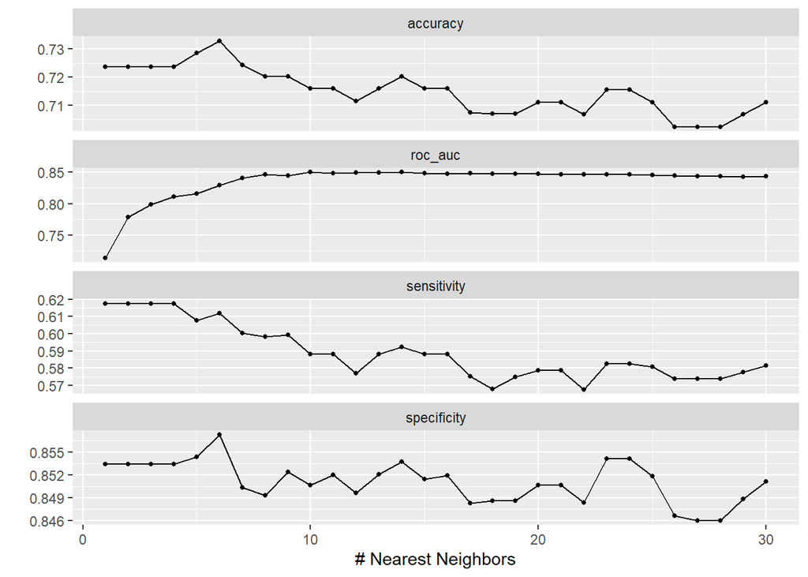

kNN Tuning: ROC AUC vs. Neighbors

**SVM (Linear Kernel)**

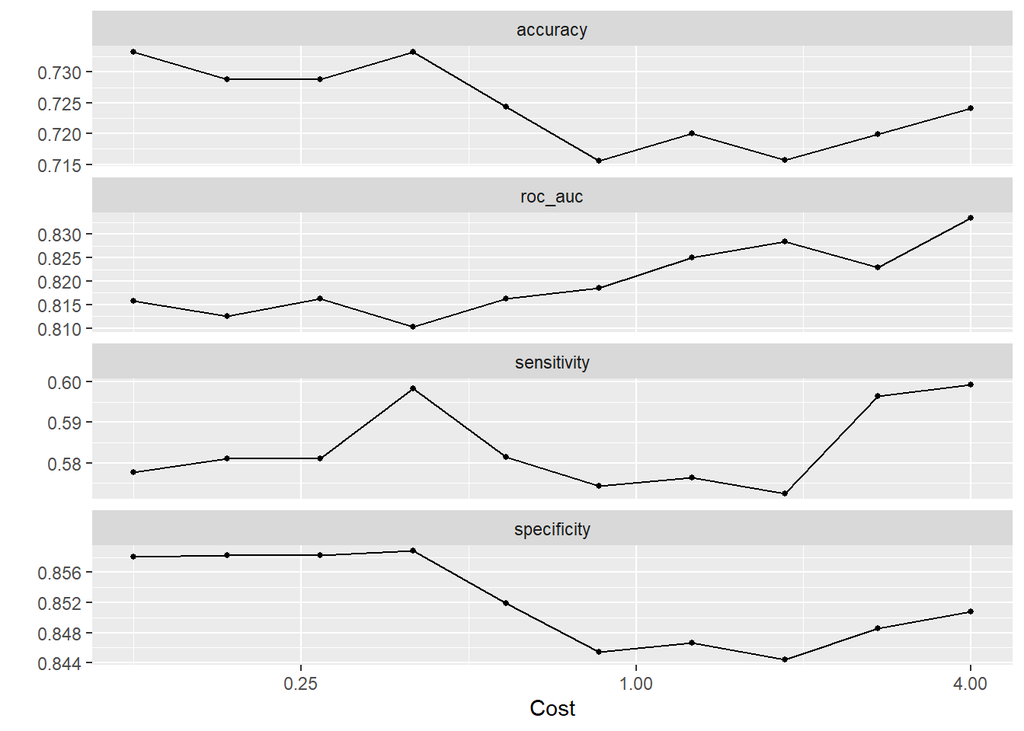

SVM Linear Tuning: ROC AUC vs. Cost

**Decision Tree**

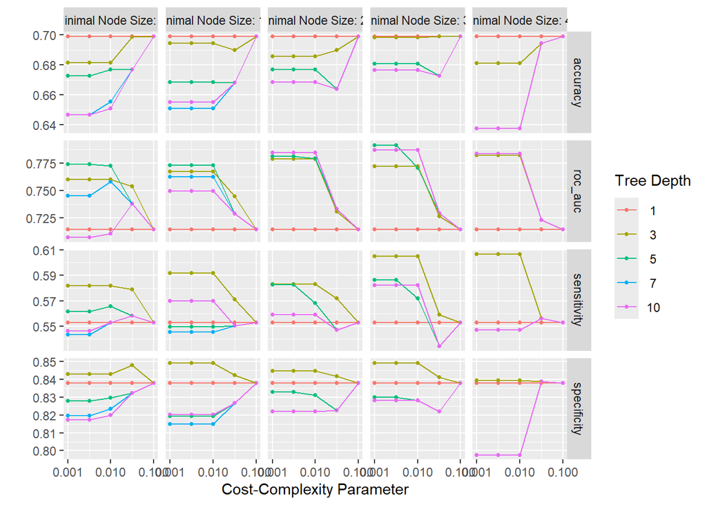

Decision Tree Tuning

**Random Forest**

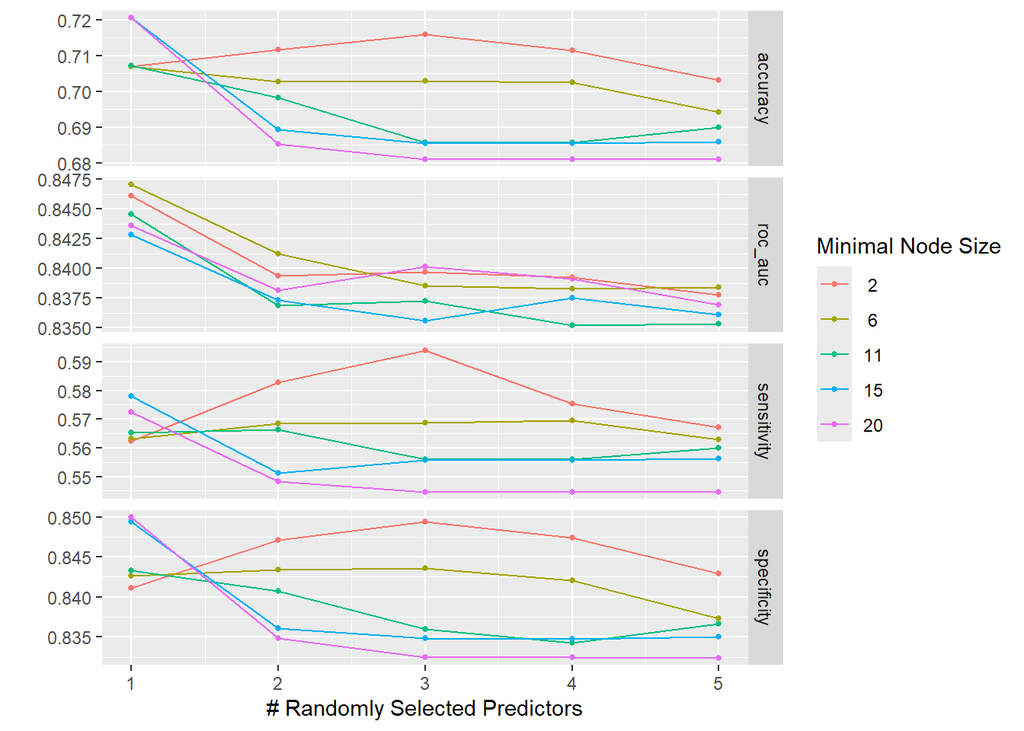

Random Forest Tuning

## Model Comparison (Cross-Validation Performance)

**Show R Code**

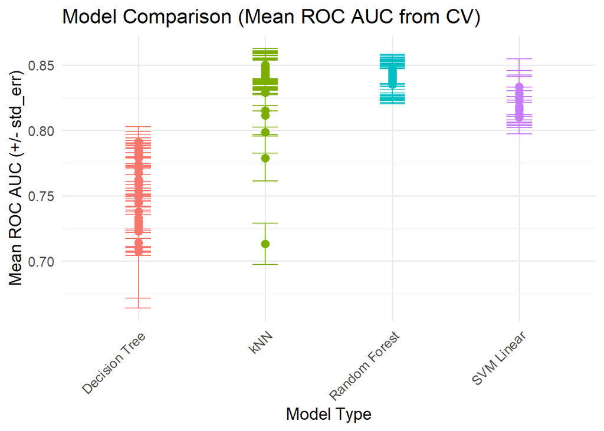

```r
comparison_plot <- tar_read(tuning_comparison_plot)
print(comparison_plot)
```

**Show R Code**

```r
all_tuning_summary_data <- tar_read(all_models_tuning_summary)

all_tuning_summary_data |>
  filter(.metric == "roc_auc") |>
  select(
    model,
    mean_roc_auc = mean,
    std_err_roc_auc = std_err,
    n_configs_tuned = n
  ) |>
  arrange(desc(mean_roc_auc)) |>
  datatable(
    filter = "top",
    caption = "Summary of Best ROC AUC from Cross-Validation Tuning"
  )
```

|  | model | mean_roc_auc | std_err_roc_auc | n_configs_tuned |
| --- | --- | --- | --- | --- |
| 1 | kNN | 0.8501582319357255 | 0.01054978098203612 | 5 |
| 2 | kNN | 0.8499661392883898 | 0.01282970288364155 | 5 |
| 3 | kNN | 0.849582046257238 | 0.01122821305637523 | 5 |
| 4 | kNN | 0.8494305495584268 | 0.01128904760373132 | 5 |
| 5 | kNN | 0.8486948402549426 | 0.01182632498430205 | 5 |
| 6 | kNN | 0.8480810418150571 | 0.01069691603889189 | 5 |
| 7 | kNN | 0.8478997747539947 | 0.01120347129742384 | 5 |
| 8 | kNN | 0.8478744945496863 | 0.00954544365421248 | 5 |
| 9 | kNN | 0.8478066808629469 | 0.0107512457556806 | 5 |
| 10 | kNN | 0.8474306455124869 | 0.01009671366479057 | 5 |

[output cut: 180 more lines]

Based on the cross-validation results, Random Forest appears to be a strong candidate.

## Final Model Evaluation: Random Forest

The Random Forest model, using its best hyperparameters found during tuning, was finalized by fitting it to the entire training dataset. It was then evaluated on the held-out test set.

**Show R Code**

```r
final_rf_metrics_data <- tar_read(final_rf_metrics)
final_rf_conf_matrix_obj <- tar_read(final_rf_conf_matrix)
final_rf_vip_plot_obj <- tar_read(final_rf_vip_plot)
```

### Test Set Performance Metrics

|  | Metric | Estimator | Estimate |
| --- | --- | --- | --- |
| 1 | accuracy | multiclass | 0.7326732673267327 |
| 2 | sensitivity | macro | 0.6114604400318685 |
| 3 | specificity | macro | 0.857101595110316 |
| 4 | roc_auc | hand_till | 0.7877367163081448 |

### Confusion Matrix

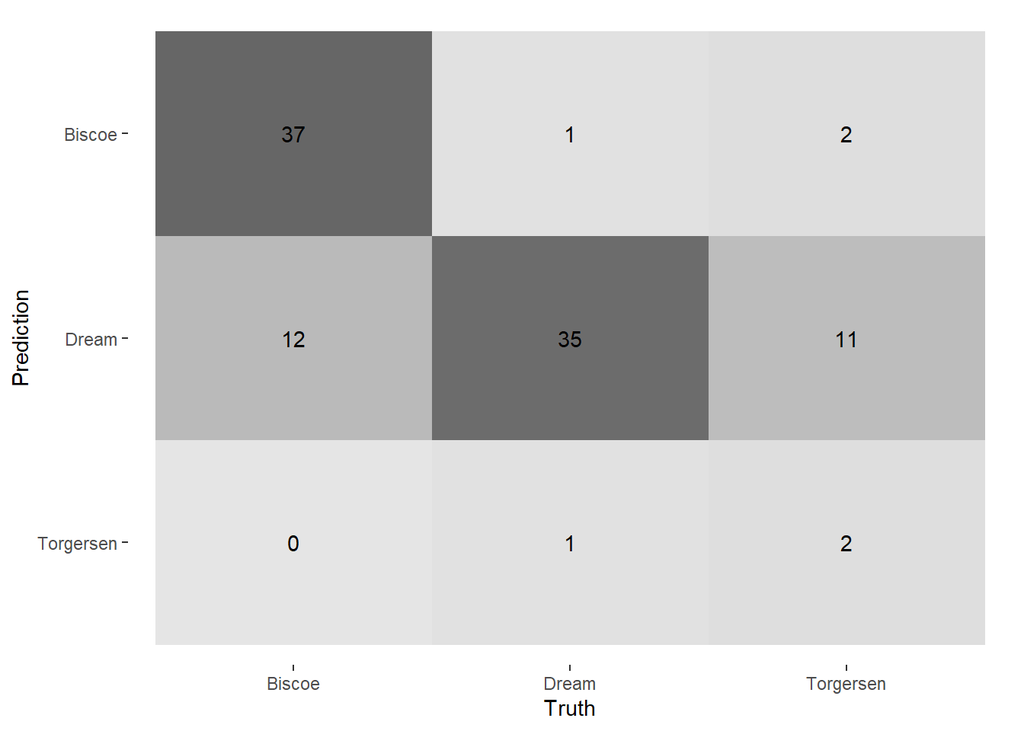

Confusion Matrix for Final Random Forest Model (Test Set)

### Variable Importance

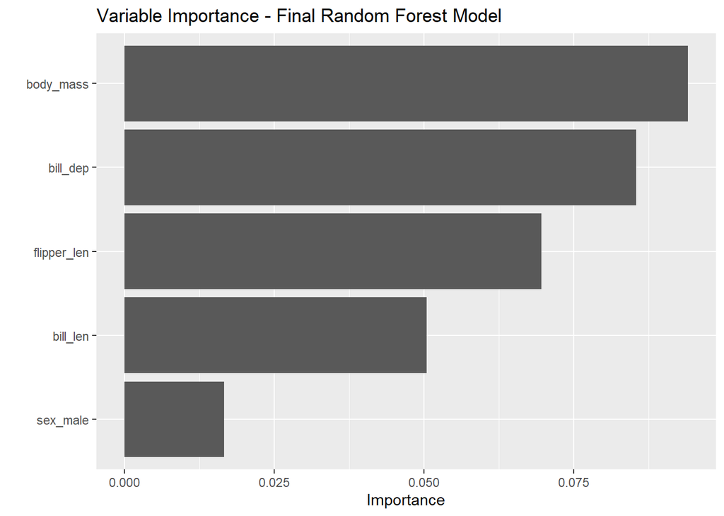

Variable Importance for Final Random Forest Model

## Conclusion

The `tidymodels` framework, orchestrated by `targets`, provides a powerful and organized approach to machine learning. This workflow demonstrated:

- **Modularity**: Clear separation of data processing, model specification, tuning, and evaluation.
- **Uniformity**: Consistent syntax for various modeling tasks.
- **Robustness**: Reliable performance estimates through cross-validation.
- **Reproducibility**: The entire analysis can be easily rerun and verified.

The Random Forest model showed strong performance on this classification task. Further improvements could involve exploring more complex feature engineering, different model types, or more advanced tuning strategies like Bayesian optimization.

*Report generated on: 2025-05-30* *All code and results are managed by the `targets` pipeline.*